# MM5

2023-12-02

# 1

Plot the data

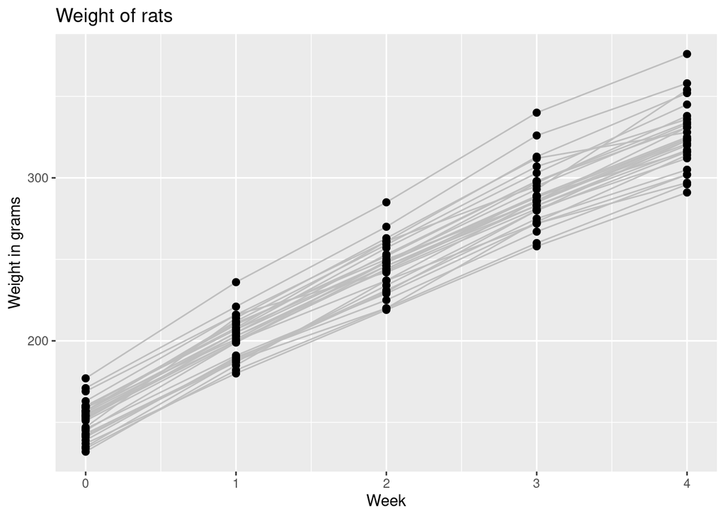

```r
ggplot(ratData, aes(x = week, y = y)) + geom_line(aes(x = week, y = y, group = rat), linetype = "solid", color = "gray") + geom_point(size = 2) + xlab("Week") +  ylab("Weight in grams") + ggtitle("Weight of rats")
```

# 2.

Fit four models

```r
model1 <- lmer(y ~ week + (1 | rat), data = ratData)
model2 <- lmer(y ~ week + (1 + week || rat), data = ratData)
model3 <- lmer(y ~ week + (1 + week | rat), data = ratData)
model4 <- lmer(y ~ week + (week | rat), data = ratData)
```

Each model has the weight of rats of the response, and each of them has week as a fixed effect. Models are described in words below

1. Rat enters as a random effect on the intercept. This means that each rat has it’s own random birthweight.
2. Rat enters as both a random effect on the intercept and slope of week. This means that each rat has it’s random slope (i.e. growth rate per week) and intercept as described in 1. The double bar syntax indicates that the random effects between growth rate and birth weight are independent.
3. The same as 2, but we allow for dependence between growth rate and birthweight.
4. R by default adds a random intercept when including a random slope. This model is the same as 3.

# 3.

We compute confidence intervals for model 4.

```r
confint(model4)
```

```
## Computing profile confidence intervals ...
```

```
##                   2.5 %      97.5 %
## .sig01        7.9966221  14.6532950
## .sig02       -0.2530694   0.6083596
## .sig03        2.4725802   4.8289939
## .sigma        5.0609231   6.7829731
## (Intercept) 151.7561121 160.3505546
## week         41.8186082  44.7147252
```

.sig01 corresponds to the confidence interval for the random intercept variance, .sig02 corresponds to the correlation estimate between the random intercept and random slope, .sig03 corresponds to the random slope. .sigma is the residual variance. Intercept and week are fixed effects and are interpreted as usual.

# 4.

```r
ratData <- ratData %>% mutate(bef_week_2 = case_when(week <= 2 ~ "Y",
                             TRUE ~ "N"))
```

and consider the model

```r
model5 <- lmer(y ~ week + week:bef_week_2 + (week | rat), data = ratData)
```

The positive parameter on the interaction term indicates that there could be higher growth rate in the first two weeks. We compute confidence intervals

```r
confint(model5)
```

```
## Computing profile confidence intervals ...
```

```
##                        2.5 %      97.5 %
## .sig01             8.2209568  14.7701292
## .sig02            -0.2698621   0.5503963
## .sig03             2.5948958   4.8876631
## .sigma             4.6074444   6.1751919
## (Intercept)      149.7814587 158.5368212
## week              42.0516324  44.9552493
## week:bef_week_2Y   1.2797721   3.4557118
```

Which is an indication that our suspicion is correct.